# IE 48B — Homework 3

Generalized Additive Models: Solar Power Forecasting

Author

**Yunus Emre Camızcı** | Student ID: **2021402078**

Published

May 4, 2026

**ImportantData Collection**

You are responsible for downloading and preparing the data yourself. See the problem statement PDF for details on sources and suggested locations.

- **Target:** Hourly solar generation (MW) from [EPIAS Transparency Platform](https://seffaflik.epias.com.tr/electricity/electricity-generation/ex-post-generation/real-time-generation)
- **Predictors:** Hourly weather data from [Open-Meteo Historical Weather API](https://open-meteo.com/en/docs/historical-weather-api)
- **Time span:** January 2022 – March 2026

> **Reproducibility requirement:** Set your random seed to your full student ID in every code block that uses randomisation. Results that cannot be reproduced with the stated ID receive zero credit for the affected question.

> **Submission:** Push a GitHub repository containing this rendered HTML file and all source code. Repository structure must follow the course template.

**TipWork incrementally — commit after each part**

After completing each part, render the document and push your progress:

```bash
quarto render HW3_GAMs_SolarForecasting.qmd
git add HW3_GAMs_SolarForecasting.qmd \
        HW3_GAMs_SolarForecasting.html
git commit -m "Complete Part 3: GAM modeling"
git push
```

**Your commit history is assessed.** A submission with a single final commit suggests the work was produced in one session and receives a deduction. Aim for at least one commit per part.

# 1 Part 1 — Data Collection and Exploratory Analysis (20 pts)

## 1.1 Data Collection and Preparation (8 pts)

Download the solar generation data from EPIAS and the weather data from Open-Meteo. Merge them into a single hourly data frame and create useful derived columns.

Describe your data collection process: which variables did you download, from which locations, and how did you handle merging, missing values, and timezone alignment? Report the final dimensions of your dataset. (3–5 sentences.)

```python
import numpy as np
import pandas as pd
import matplotlib.pyplot as plt
import matplotlib.dates as mdates
import seaborn as sns
from matplotlib.patches import Patch

STUDENT_ID = 2021402078
np.random.seed(STUDENT_ID % 2**31)

sns.set_theme(style="whitegrid", palette="muted", font_scale=1.1)
plt.rcParams.update({"figure.dpi": 120, "axes.spines.top": False, "axes.spines.right": False})

SEASON_COLORS = {"Winter": "#4878CF", "Spring": "#6ACC65", "Summer": "#D65F5F", "Autumn": "#B47CC7"}

def get_season(month):
    if month in [12, 1, 2]:  return "Winter"
    elif month in [3, 4, 5]: return "Spring"
    elif month in [6, 7, 8]: return "Summer"
    else:                     return "Autumn"

df = pd.read_csv("data/solar_dataset.csv", parse_dates=["datetime"])
if df["datetime"].dt.tz is None:
    df["datetime"] = df["datetime"].dt.tz_localize("Europe/Istanbul")

df["date"]        = pd.to_datetime(df["datetime"].dt.date)
df["year"]        = df["datetime"].dt.year
df["month"]       = df["datetime"].dt.month
df["hour"]        = df["datetime"].dt.hour
df["day_of_year"] = df["datetime"].dt.dayofyear
df["season"]      = df["month"].map(get_season)

print(f"Dataset shape  : {df.shape[0]:,} rows x {df.shape[1]} columns")
print(f"Date range     : {df['datetime'].min()} -> {df['datetime'].max()}")
print(f"Missing values : {df.isnull().sum().sum()}")
```

```
Dataset shape  : 37,224 rows x 35 columns
Date range     : 2022-01-01 00:00:00+03:00 -> 2026-03-31 23:00:00+03:00
Missing values : 0
```

Hourly solar generation data were downloaded from the EPİAŞ Transparency Platform using the `eptr2` Python package (`rt-gen` call), covering January 2022 through March 2026 in 51 monthly API requests. Weather data were obtained from the Open-Meteo Historical Weather API for three locations representing Turkey’s main solar capacity regions: Konya (37.87°N, 32.48°E), Gaziantep (37.07°N, 37.38°E), and İzmir (38.42°N, 27.14°E), with variables including shortwave radiation, direct radiation, cloud cover, temperature, precipitation, and wind speed. Both sources report in Turkey Standard Time (UTC+3), so no timezone shift was required before merging on the hourly datetime index. No missing values were found after the inner join. The final dataset contains 37,224 rows and 35 columns, including the target variable `solar_mwh`, 18 location-specific weather columns, 6 location-averaged aggregates, and calendar features (hour, month, day-of-year, season, weekday).

## 1.2 Exploratory Analysis (12 pts)

Produce at least two visualisations that reveal the main patterns in solar generation: one showing the long-run behaviour (trend, annual seasonality) and one showing the within-day pattern and how it varies across seasons. Describe what you observe. (3–5 sentences total.)

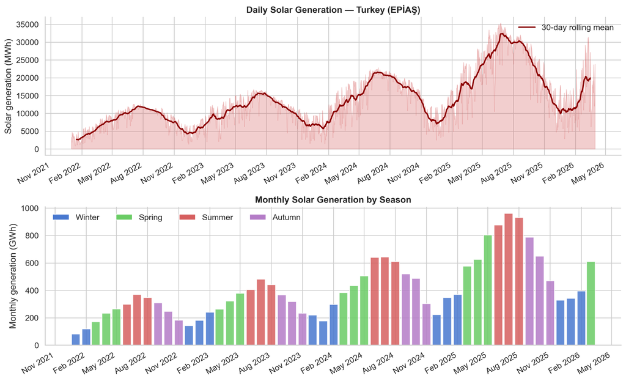

```python
np.random.seed(STUDENT_ID % 2**31)

daily = (df.groupby("date")["solar_mwh"].sum().reset_index().rename(columns={"solar_mwh": "daily_mwh"}))

monthly = (df.groupby(["year", "month"])["solar_mwh"].sum().reset_index().rename(columns={"solar_mwh": "monthly_mwh"}))
monthly["date"] = pd.to_datetime(monthly["year"].astype(str) + "-" + monthly["month"].astype(str).str.zfill(2) + "-01")

fig, axes = plt.subplots(2, 1, figsize=(13, 8))

ax = axes[0]
ax.fill_between(daily["date"], daily["daily_mwh"], alpha=0.3, color="#D65F5F")
rolling = daily.set_index("date")["daily_mwh"].rolling(30, center=True).mean()
ax.plot(rolling.index, rolling.values, color="#8B0000", lw=2, label="30-day rolling mean")
ax.set_ylabel("Solar generation (MWh)")
ax.set_title("Daily Solar Generation — Turkey (EPİAŞ)", fontweight="bold")
ax.legend(frameon=False)
ax.xaxis.set_major_formatter(mdates.DateFormatter("%b %Y"))
ax.xaxis.set_major_locator(mdates.MonthLocator(interval=3))
plt.setp(ax.xaxis.get_majorticklabels(), rotation=30, ha="right")

ax2 = axes[1]
colors = [SEASON_COLORS[get_season(m)] for m in monthly["month"]]
ax2.bar(monthly["date"], monthly["monthly_mwh"] / 1000, width=25, color=colors, alpha=0.85, edgecolor="white")
ax2.set_ylabel("Monthly generation (GWh)")
ax2.set_title("Monthly Solar Generation by Season", fontweight="bold")
ax2.xaxis.set_major_formatter(mdates.DateFormatter("%b %Y"))
ax2.xaxis.set_major_locator(mdates.MonthLocator(interval=3))
plt.setp(ax2.xaxis.get_majorticklabels(), rotation=30, ha="right")
legend_els = [Patch(facecolor=v, label=k) for k, v in SEASON_COLORS.items()]
ax2.legend(handles=legend_els, frameon=False, ncol=4)

plt.tight_layout()
plt.show()
```

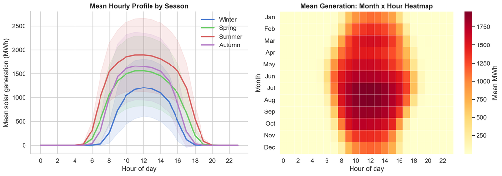

```python
np.random.seed(STUDENT_ID % 2**31)

hourly_season = df.groupby(["season", "hour"])["solar_mwh"].agg(["mean", "std"]).reset_index()

fig, axes = plt.subplots(1, 2, figsize=(14, 5))

ax = axes[0]
for seas in ["Winter", "Spring", "Summer", "Autumn"]:
    grp = hourly_season[hourly_season["season"] == seas]
    ax.plot(grp["hour"], grp["mean"], label=seas, color=SEASON_COLORS[seas], lw=2.5)
    ax.fill_between(grp["hour"], grp["mean"] - grp["std"], grp["mean"] + grp["std"], alpha=0.12, color=SEASON_COLORS[seas])
ax.set_xlabel("Hour of day")
ax.set_ylabel("Mean solar generation (MWh)")
ax.set_title("Mean Hourly Profile by Season", fontweight="bold")
ax.set_xticks(range(0, 24, 2))
ax.legend(frameon=False)

ax2 = axes[1]
pivot = df.groupby(["month", "hour"])["solar_mwh"].mean().unstack("hour")
sns.heatmap(pivot, cmap="YlOrRd", ax=ax2, cbar_kws={"label": "Mean MWh"}, linewidths=0.3, linecolor="white")
ax2.set_xlabel("Hour of day")
ax2.set_ylabel("Month")
ax2.set_yticklabels(["Jan","Feb","Mar","Apr","May","Jun","Jul","Aug","Sep","Oct","Nov","Dec"], rotation=0)
ax2.set_title("Mean Generation: Month x Hour Heatmap", fontweight="bold")

plt.tight_layout()
plt.show()
```

Explore the relationship between the weather variables and solar generation. Use appropriate visualisations. Which weather variable(s) are the strongest predictors? Are the relationships linear or nonlinear? (3–5 sentences.)

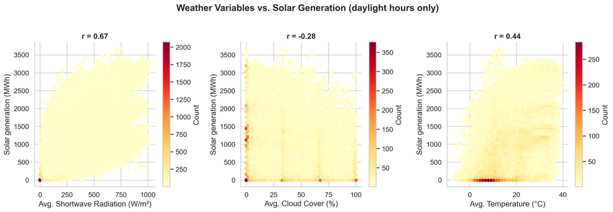

```python
np.random.seed(STUDENT_ID % 2**31)

df_day = df[df["hour"].between(6, 19)].copy()

fig, axes = plt.subplots(1, 3, figsize=(15, 5))

weather_vars = [
    ("avg_shortwave_radiation", "Avg. Shortwave Radiation (W/m²)"),
    ("avg_cloud_cover",         "Avg. Cloud Cover (%)"),
    ("avg_temperature_2m",      "Avg. Temperature (°C)"),
]

for ax, (var, label) in zip(axes, weather_vars):
    hb   = ax.hexbin(df_day[var], df_day["solar_mwh"], gridsize=40, cmap="YlOrRd", mincnt=1)
    corr = df_day[[var, "solar_mwh"]].corr().iloc[0, 1]
    plt.colorbar(hb, ax=ax, label="Count")
    ax.set_xlabel(label)
    ax.set_ylabel("Solar generation (MWh)")
    ax.set_title(f"r = {corr:.2f}", fontweight="bold")

plt.suptitle("Weather Variables vs. Solar Generation (daylight hours only)", y=1.02, fontweight="bold")
plt.tight_layout()
plt.show()
```

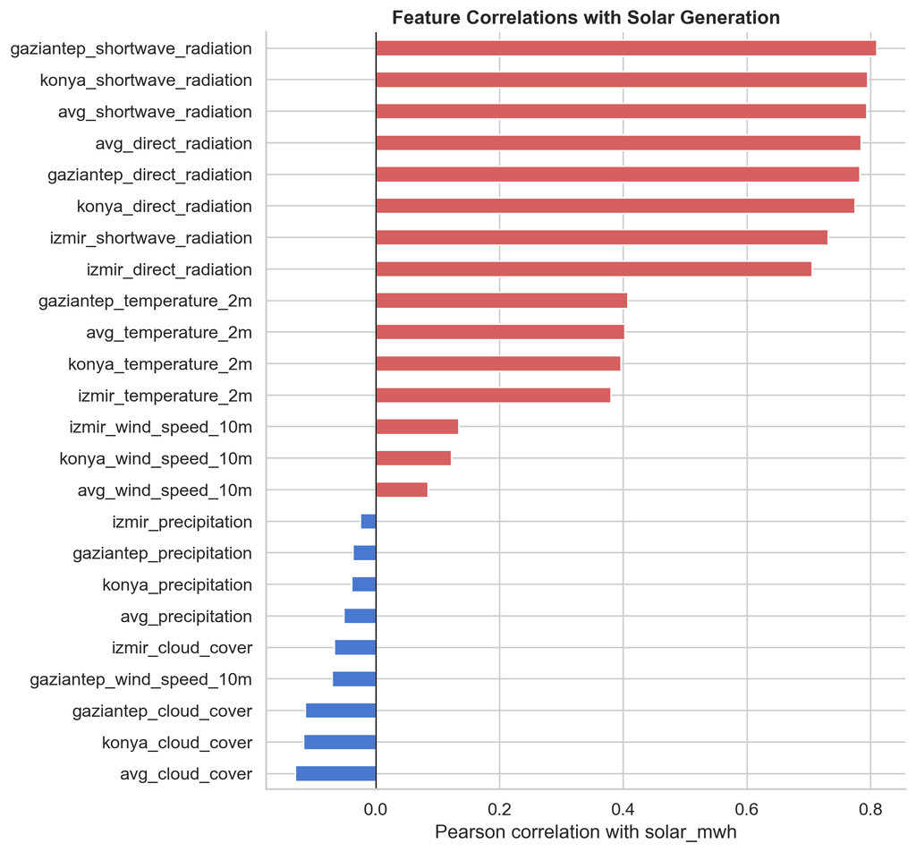

```
Top 5 positive correlations:
gaziantep_direct_radiation       0.782
avg_direct_radiation             0.785
avg_shortwave_radiation          0.794
konya_shortwave_radiation        0.795
gaziantep_shortwave_radiation    0.810

Top 5 negative correlations:
avg_cloud_cover            -0.130
konya_cloud_cover          -0.117
gaziantep_cloud_cover      -0.114
gaziantep_wind_speed_10m   -0.070
izmir_cloud_cover          -0.067
```

```python
np.random.seed(STUDENT_ID % 2**31)

weather_cols = [c for c in df.columns if any(
    v in c for v in ["radiation", "cloud", "temperature", "precipitation", "wind_speed"])]

corr_series = (df[weather_cols + ["solar_mwh"]]
               .corr()["solar_mwh"]
               .drop("solar_mwh")
               .sort_values())

fig, ax = plt.subplots(figsize=(9, max(4, len(corr_series) * 0.35)))
colors = ["#D65F5F" if v > 0 else "#4878CF" for v in corr_series]
corr_series.plot(kind="barh", ax=ax, color=colors, edgecolor="white")
ax.axvline(0, color="black", lw=0.8)
ax.set_xlabel("Pearson correlation with solar_mwh")
ax.set_title("Feature Correlations with Solar Generation", fontweight="bold")
plt.tight_layout()
plt.show()

print("Top 5 positive correlations:")
print(corr_series.tail(5).round(3).to_string())
print("\nTop 5 negative correlations:")
print(corr_series.head(5).round(3).to_string())
```

# 2 Part 2 — Baseline Models (15 pts)

## 2.1 Train/Test Split (3 pts)

Split the data chronologically:

- **Training set:** All data before January 1, 2026
- **Test set:** January 1 – March 31, 2026

```python
np.random.seed(STUDENT_ID % 2**31)

df["datetime_naive"] = df["datetime"].dt.tz_localize(None)

train = df[df["datetime_naive"] < pd.Timestamp("2026-01-01")].copy()
test  = df[(df["datetime_naive"] >= pd.Timestamp("2026-01-01")) &
           (df["datetime_naive"] <= pd.Timestamp("2026-03-31 23:00:00"))].copy()

print(f"Training set: {len(train):,} observations ({train['datetime'].min().date()} to {train['datetime'].max().date()})")
print(f"Test set    : {len(test):,} observations ({test['datetime'].min().date()} to {test['datetime'].max().date()})")
```

```
Training set: 35,064 observations (2022-01-01 to 2025-12-31)
Test set    : 2,160 observations (2026-01-01 to 2026-03-31)
```

| Set | Number of hourly observations |
| --- | --- |
| Training | 35,064 |
| Test | 2,160 |

## 2.2 Naive and Linear Baselines (12 pts)

Fit at least two baseline models that do **not** use smooth terms. Report the test RMSE for each baseline. Explain what each baseline captures and what it misses. What motivates moving to a GAM? (3–4 sentences.)

```python
np.random.seed(STUDENT_ID % 2**31)

from sklearn.linear_model import LinearRegression
from sklearn.metrics import mean_squared_error
import numpy as np

def rmse(y_true, y_pred):
    return np.sqrt(mean_squared_error(y_true, y_pred))

# ── Baseline 1: Mean generation per month-hour combination ────────────────────
month_hour_means = (train.groupby(["month", "hour"])["solar_mwh"]
                        .mean()
                        .reset_index()
                        .rename(columns={"solar_mwh": "pred_b1"}))

test_b1 = test.merge(month_hour_means, on=["month", "hour"], how="left")
rmse_b1 = rmse(test_b1["solar_mwh"], test_b1["pred_b1"])
print(f"Baseline 1 (Month-Hour Mean) Test RMSE: {rmse_b1:.2f} MWh")

# ── Baseline 2: Linear regression with calendar + weather features ─────────────
features = ["hour", "month", "day_of_year",
            "avg_shortwave_radiation", "avg_cloud_cover", "avg_temperature_2m"]

X_train = train[features].fillna(0)
X_test  = test[features].fillna(0)
y_train = train["solar_mwh"]
y_test  = test["solar_mwh"]

lr = LinearRegression()
lr.fit(X_train, y_train)
pred_b2 = lr.predict(X_test)
rmse_b2 = rmse(y_test, pred_b2)
print(f"Baseline 2 (Linear Regression)  Test RMSE: {rmse_b2:.2f} MWh")
```

```
Baseline 1 (Month-Hour Mean) Test RMSE: 576.62 MWh
Baseline 2 (Linear Regression)  Test RMSE: 647.18 MWh
```

| Model | Test RMSE |
| --- | --- |
| Baseline 1: Month-Hour Mean | 576.62 |
| Baseline 2: Linear Regression | 647.18 |

# 3 Part 3 — GAM Modeling (30 pts)

## 3.1 Initial GAM (10 pts)

Start with a GAM that uses calendar variables as smooth terms. Report the model specification (which terms, basis types, $k$). Report the test RMSE. Plot the partial dependence plots. Do the estimated shapes align with the patterns from your EDA? (2–3 sentences.)

[output not shown]

## 3.2 Expanded GAM (10 pts)

Extend your initial GAM by incorporating weather covariates and/or other features you consider relevant. You decide which variables to add, how many smooth terms to use, and whether interactions are appropriate.

Report the model specification and test RMSE. Show the partial dependence plots for the new terms. How much did the additional terms improve the model? (2–3 sentences.)

[output not shown]

## 3.3 Diagnostics and Refinement (10 pts)

Diagnose your expanded GAM using residual analysis. Examine the residuals for patterns over time, autocorrelation (ACF), and heteroscedasticity.

Present your diagnostic plots and describe what they reveal. Based on your findings, propose and implement **at least one refinement** to the model. Report the test RMSE before and after refinement.

### 3.3.1 Summary Table

Present a summary table comparing **all models** you have fitted. Which model performs best on the test set, and why? (2–3 sentences.)

[output not shown]

# 4 Part 4 — Forecast Evaluation (25 pts)

Using your best model from Part 3:

## 4.1 Daily Performance (13 pts)

Compute the RMSE for each day in the test set separately. Plot the daily RMSE as a time series. Identify the days where the model performs worst and investigate why. (3–4 sentences.)

Compare the predicted and actual **daily total** generation across the test period. Is the model better at predicting daily totals than individual hours? Why might this be the case? (2–3 sentences.)

## 4.2 Detailed Day Analysis (12 pts)

Select one day where the model performs well and one where it performs poorly. For each day, plot the actual and predicted hourly generation side by side. What distinguishes the model’s performance on these two days? (2–3 sentences.)

Are there systematic differences in model accuracy across the three months in the test set? Report the monthly RMSE and relate any differences to the characteristics of solar generation in those months. (2–3 sentences.)

[output not shown]

# Decision Log (10 pts)

Write **300–400 words** addressing the three prompts below. Graded on **specificity and honesty** — reference specific numbers, plots, and models from your analysis.

1. **Model building narrative:** Describe the progression from your baseline to your best model. At each step, what specific diagnostic or result motivated the next change? Reference at least two specific RMSE values.
2. **One surprising finding:** Something about the relationship between weather and solar generation, or about the GAM’s behaviour, that you did not expect. Reference a specific plot or number.
3. **Limitations:** What are the main limitations of your best model? What additional data or model features would you add if you had more time? Be specific — name the variable or technique and explain how it would address a weakness you observed.